# South East Queensland Address Density Analysis

Ashlee Poeppmann

2026-08-03

## 1 Objective

Which localities in South East Queensland have the highest density of addresses relative to land area?

## 2 Data Sources

- **Locality Boundaries**
  - Feature Service | WGS84 EPSG:3857
  - Available here: https://spatial-gis.information.qld.gov.au/arcgis/rest/services/Boundaries/AdministrativeBoundaries/MapServer/2
  - 4.0 Creative Common Licence
  - Source: Queensland Department of Natural Resources and Mines, Manufacturing and Regional and Rural Development
  - While Queensland Locality Boundaries data is available in several formats, using a feature service enables real-time access to the most current, accurate data. This also makes the analysis more reproducible, since the code queries live data directly, it can be uploaded to GitHub and re-run in the future and will still reflect accurate, up-to-date locality boundaries, even as boundaries change over time.
- **Property Address Queensland**
  - Text data package | GDA1994 EPSG:4283
  - Downloaded from https://www.data.qld.gov.au/dataset/property-address-queensland-by-area-of-interest
    - Clipped by South East Queensland (SEQ) extents
  - 4.0 Creative Common Licence
  - Source: Queensland Department of Natural Resources and Mines, Manufacturing and Regional and Rural Development
  - While there is an Address Feature Service, there are 2,835,059 addresses in the data set for Queensland, and 1,979,261 for SEQ. This server’s per-request limit is 10,000, and applies regardless of how the query is filtered. Pulling nearly 2 million rows via REST pagination would mean roughly 200+ separate paginated requests.

## 3 Definitions, Assumptions & Scope

- Localities and Suburbs = “suburbs” refer to urban areas, while rural and regional areas are referred to “localities”. However “localities” can be used for both rural and urban, so “Localities” referencing will be used in this report.
- Local Authority = Local Government Area (LGA)
- South East Queensland (SEQ) = Brisbane City, Gold Coast City, Somerset Regional, Sunshine Coast Regional, Moreton Bay City, Redland City, Logan City, Noosa Shire, Scenic Rim Regional, Ipswich City, Lockyer Valley Regional, Toowoomba Regional
- SEQ was chosen as it’s a smaller selection of data that’s easier to process for a simple analysis. Future analysis could contain all of Queensland.
- WGS84 EPSG:4326 = a geographic coordinate system using latitude and longitude measured in degrees. Required by Leaflet and most web-based mapping libraries to render correctly; used in this project for the final interactive map only.
- EPSG:3857 (Web Mercator) = a projected coordinate system measured in metres, widely used as the default system for web map tiles (e.g., OpenStreetMap, Google Maps). Used in this project as the common CRS for spatial joins and area calculations.
- The Property Address Queensland dataset does not represent residential addresses exclusively, it also includes addresses for businesses, services, and institutions such as hospitals, schools, and universities. Therefore this analysis does not measure residential population density, but rather address density: the concentration of all registered, addressable locations — residential, commercial, and institutional — within a given area.
- A locality with a large hospital, university campus, or shopping precinct may consequently show high address density without a correspondingly high resident population.
- This analysis was conducted using R, with Claude (Anthropic) used to assist in code generation, debugging, and troubleshooting throughout the development process. All analytical decisions, interpretation of results, and discussion presented in this report are my own.

## 4 Methodology

### 4.1 Loading and Preparing the Data

#### 4.1.1 Queensland Locality Boundaries

```r
# Reading directly from an ArcGIS Feature Service REST endpoint
localities_web <- read_sf("https://spatial-gis.information.qld.gov.au/arcgis/rest/services/Boundaries/AdministrativeBoundaries/MapServer/2/query?where=lga+IN+%28%27Brisbane+City%27%2C+%27Gold+Coast+City%27%2C+%27Somerset+Regional%27%2C+%27Sunshine+Coast+Regional%27%2C+%27Moreton+Bay+City%27%2C+%27Redland+City%27%2C+%27Logan+City%27%2C+%27Noosa+Shire%27%2C+%27Scenic+Rim+Regional%27%2C+%27Ipswich+City%27%2C+%27Lockyer+Valley+Regional%27%2C+%27Toowoomba+Regional%27%29&outFields=*&returnGeometry=true&f=geojson")
```

Queensland has a number of locality names that repeat across different local government areas, Example: Tamborine (Logan City) and Tamborine (Scenic Rim Regional). To avoid duplication, I’ll join Locality to (LGA) for labeling purposes in the graphs and maps. (we could also use the column name = ’loc_code” but for labeling purposes I’ve gone with the names.)

```r
localities_web <- localities_web %>%
  mutate(locality_base = str_remove(locality, " \\(.*\\)$"))

dupe_names <- localities_web %>%
  st_drop_geometry() %>%
  count(locality_base) %>%
  filter(n > 1) %>%
  pull(locality_base)

localities_web <- localities_web %>%
  mutate(locality = if_else(
    locality_base %in% dupe_names,
    paste0(locality_base, " (", lga, ")"),
    locality_base
  ))

#Force correct crs - in EPSG:4326 but we want 3857 for spatial data analysis
localities_web <- st_transform(localities_web, crs = 3857)
```

Checking how the data looks, and confirming the datum.

```r
#total localities
nrow(localities_web)
```

```
## [1] 1189
```

```r
#Check Datum
st_crs(localities_web)$input
```

```
## [1] "EPSG:3857"
```

```r
#sanity check above (LGA) append worked
localities_web %>%
  st_drop_geometry() %>%
  filter(str_detect(locality, "Tamborine")) %>%
  select(locality, lga)
```

```
## # A tibble: 3 × 2
##   locality                        lga
##   <chr>                           <chr>
## 1 Tamborine Mountain              Scenic Rim Regional
## 2 Tamborine (Logan City)          Logan City
## 3 Tamborine (Scenic Rim Regional) Scenic Rim Regional
```

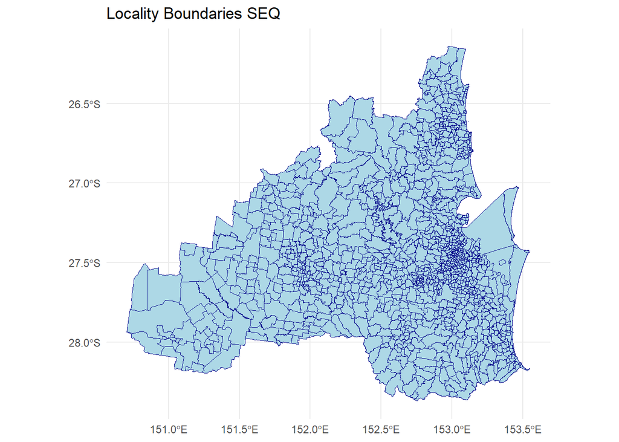

```r
#Quick map view
localities_web %>%
  ggplot() +
  geom_sf(fill = "lightblue", color = "darkblue", linewidth = 0.1) +
  theme_minimal() +
  labs(title = "Locality Boundaries SEQ")
```

#### 4.1.2 Property Address Queensland

The text data download includes a column on what datum to use, so I have loaded it in as EPSG:4283 GDA94. Plus I will convert the LOCAL_AUTHORITY field to sentence case sine they are all in capitals

```r
#Read in text file and state delimeter.
addresses_raw <- read_delim(
  "data/Property_address_Queensland.txt",
  delim = "|",
  col_types = cols(LATITUDE = col_double(), LONGITUDE = col_double(), .default = col_character())
)

#add lat and longs from table
addresses_sf <- st_as_sf(
  addresses_raw,
  coords = c("LONGITUDE", "LATITUDE"),
  crs = 4283,
  remove = FALSE
)

#change casing of LOCAL_AUTHORITY attributes
addresses_sf <- addresses_sf %>%
  mutate(LOCAL_AUTHORITY = str_to_title(LOCAL_AUTHORITY))
```

I need to filter out only SEQ. We also only want the Status = P not A, as P = Primary address. Alternative addresses in the data are ‘second’ addresses, usually reserved for corner blocks.

Locality boundary data is in WGS84 EPSG:3857, while address data is in GDA94; all layers need to be transformed to a common CRS prior to spatial analysis. I’ve chosen WGS84 EPSG:3857 as later in this report we will be mapping to a web based application, which requires WGS84.

```r
#list of SEQ LGAs
seq_lgas <- c(
  "Brisbane City", "Gold Coast City", "Somerset Regional",
  "Sunshine Coast Regional", "Moreton Bay City", "Redland City",
  "Logan City", "Noosa Shire", "Scenic Rim Regional",
  "Ipswich City", "Lockyer Valley Regional", "Toowoomba Regional"
)

addresses_seq <- addresses_sf %>%
  filter(LOCAL_AUTHORITY %in% seq_lgas)

#Only 'P' addresses
addresses_primary <- addresses_seq %>%
  filter(ADDRESS_STATUS == "P")

#update crs
addresses_primary <- st_transform(addresses_primary, crs = 3857)
```

Checking how the data looks and confirming the datum was properly set.

```r
#total addresses
nrow(addresses_primary)
```

```
## [1] 1889301
```

```r
#Check Datum
st_crs(addresses_primary)$input
```

```
## [1] "EPSG:3857"
```

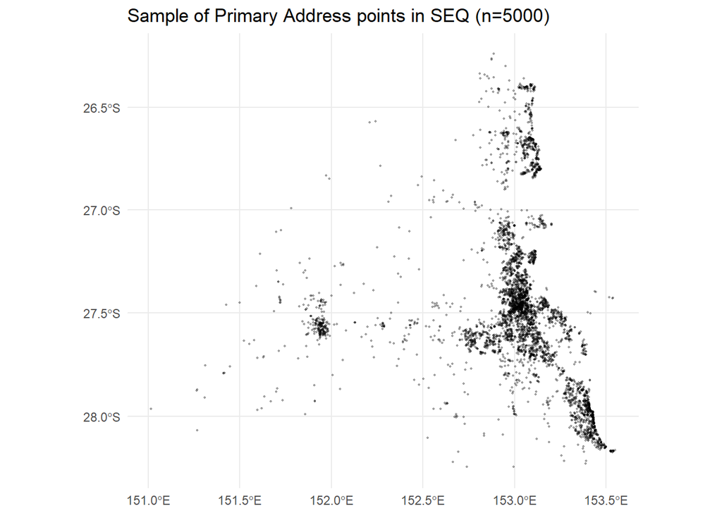

```r
#Quick map view of a sample amount
addresses_primary %>%
  slice_sample(n = 5000) %>%
  ggplot() +
  geom_sf(size = 0.3, alpha = 0.3) +
  theme_minimal() +
  labs(title = "Sample of Primary Address points in SEQ (n=5000)")
```

### 4.2 Spatial Join

Taking each point in the address layer and finds which polygon (locality) it falls inside, then attaches that polygon’s attributes to the point.

```r
#Spatial join 'within' - point must fall 'within' the polygon
addresses_joined <- st_join(
  addresses_primary,
  localities_web,
  join = st_within
)
```

Sanity Checking the join:

```r
#Number of rows from addresses
nrow(addresses_primary)
```

```
## [1] 1889301
```

```r
#nrow(addresses_joined)
nrow(addresses_joined)
```

```
## [1] 1889301
```

```r
#These two numbers should match if every point match
```

Result = 1,889,301 Both row count matches, meaning the join didn’t create duplicates or drop any address points.

Another sanity check - checking whether each address’s self-reported locality (from the original text file) agrees with the spatially-derived locality (form the join above)

```r
addresses_joined <- addresses_joined %>%
  mutate(
    LOCALITY_stripped = str_remove(LOCALITY, " \\(.*\\)$"),
    locality_stripped = str_remove(locality, " \\(.*\\)$"),
    locality_match = toupper(LOCALITY_stripped) == toupper(locality_stripped) #toupper change case
  )

table(addresses_joined$locality_match, useNA = "ifany")
```

```
##
##   FALSE    TRUE    <NA>
##    1696 1887592      13
```

```r
mean(addresses_joined$locality_match, na.rm = TRUE) * 100
```

```
## [1] 99.91023
```

**13 points** = N/A, meaning these points didn’t fall inside any locality polygon at all (likely just outside the SEQ area, data errors or boundaries that have not been updated).

**1,887,592 points (99.91%**) = the address record’s self-reported locality matches the locality polygon the point geographically falls inside

**1,696 points (~0.09%)** = a mismatch between the two sources

**Result** = 99.91% agreement rate between two fields

What boundaries causes the ~0.09% mismatch?

```r
mismatches <- addresses_joined %>%
  filter(locality_match == FALSE) %>%
  st_drop_geometry() %>%
  count(LOCALITY, locality, sort = TRUE) %>%
  head(20)

mismatches
```

```
## # A tibble: 20 × 3
##    LOCALITY                        locality                              n
##    <chr>                           <chr>                             <int>
##  1 BELLS CREEK                     Aura Central                         85
##  2 EAST BRISBANE                   Coorparoo                            46
##  3 MULDU                           Balgowan                             44
##  4 MILLMERRAN                      Yandilla                             22
##  5 ELLEN GROVE                     Forest Lake                          21
##  6 GOWRIE JUNCTION                 Glencoe                              16
##  7 WONGAWALLAN                     Willow Vale                          14
##  8 CAWDOR                          Highfields                           13
##  9 CLIFTON                         Spring Creek (Toowoomba Regional)    13
## 10 LEMONTREE                       Kurrowah                             13
## 11 MILLMERRAN                      Pampas                               12
## 12 IRVINGDALE (TOOWOOMBA REGIONAL) Bowenville                           11
## 13 PITTSWORTH                      Kincora                              11
## 14 PITTSWORTH                      Scrubby Mountain                     11
## 15 ELLANGOWAN                      Leyburn                              10
## 16 PADDINGTON                      Milton                               10
## 17 TOOWOOMBA CITY                  Darling Heights                      10
## 18 TOOWOOMBA CITY                  Harristown                           10
## 19 GROOMSVILLE                     Meringandan                           9
## 20 PITTSWORTH                      Broxburn                              9
```

Most of these are data quality errors that are out of scope to clean now. One example is BELLS CREEK vs Aura Central. [Aura Central](https://haveyoursay.nrmmrrd.qld.gov.au/bells-creek-and-aura-central-place-name-proposal) is a newly created locality, as of 25th July. Addresses have not been updated yet. I’m happy with 99.91% result.

### 4.3 Area/density calculation

Get total of addresses per locality.

```r
address_counts <- addresses_joined %>%
  st_drop_geometry() %>%
  filter(!is.na(locality)) %>%
  count(locality, name = "address_count")
```

Density calculation — joining address counts to each locality’s land area, then computing addresses per km2

```r
locality_density <- address_counts %>%
  left_join(
    localities_web %>% st_drop_geometry() %>% select(locality, ca_area_sqkm),
    by = "locality"
  ) %>%
  mutate(density_per_sqkm = address_count / ca_area_sqkm)

locality_density %>% arrange(desc(density_per_sqkm)) %>% head(10)
```

```
## # A tibble: 10 × 4
##    locality         address_count ca_area_sqkm density_per_sqkm
##    <chr>                    <int>        <dbl>            <dbl>
##  1 Newstead                  5738        0.903            6357.
##  2 Broadbeach                8963        1.45             6192.
##  3 Fortitude Valley          8108        1.37             5919.
##  4 Brisbane City            12514        2.53             4953.
##  5 Kings Beach               3075        0.627            4907.
##  6 South Brisbane           10192        2.30             4425.
##  7 Teneriffe                 3598        0.874            4117.
##  8 Spring Hill               5216        1.31             3994.
##  9 West End                  9167        2.34             3911.
## 10 Surfers Paradise         23799        6.17             3854.
```

Top 10 localities ranked by address density per km2.

Note: I’ve added a filter(address_count >= 100) to exclude any locality with fewer than 100 addresses, so a tiny locality with a handful of addresses on a very small locality can’t produce an artificially extreme density value (Like Enoggera Reservoir and Mount Coot-tha)

```r
locality_density %>%
  filter(address_count >= 100) %>%
  arrange(desc(density_per_sqkm)) %>%
  select(locality, address_count, ca_area_sqkm, density_per_sqkm) %>%
  head(10)
```

```
## # A tibble: 10 × 4
##    locality         address_count ca_area_sqkm density_per_sqkm
##    <chr>                    <int>        <dbl>            <dbl>
##  1 Newstead                  5738        0.903            6357.
##  2 Broadbeach                8963        1.45             6192.
##  3 Fortitude Valley          8108        1.37             5919.
##  4 Brisbane City            12514        2.53             4953.
##  5 Kings Beach               3075        0.627            4907.
##  6 South Brisbane           10192        2.30             4425.
##  7 Teneriffe                 3598        0.874            4117.
##  8 Spring Hill               5216        1.31             3994.
##  9 West End                  9167        2.34             3911.
## 10 Surfers Paradise         23799        6.17             3854.
```

A note for future configurations and fine tuning: joining the Local Government Areas to the above table, might help with a quick analysis of where the localities are in SEQ.

### 4.4 Visualize

#### 4.4.1 Charts

Bar chart:

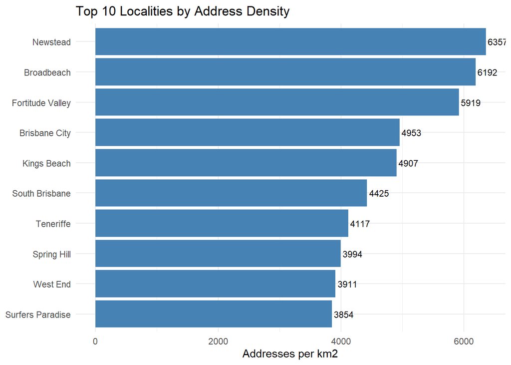

```r
locality_density %>%
  arrange(desc(density_per_sqkm)) %>%
  head(10) %>%
  ggplot(aes(x = reorder(locality, density_per_sqkm), y = density_per_sqkm)) +
  geom_col(fill = "steelblue") +
  geom_text(aes(label = round(density_per_sqkm, 0)), hjust = -0.1, size = 3) +
  coord_flip() +
  theme_minimal() +
  labs(
    title = "Top 10 Localities by Address Density",
    x = NULL,
    y = "Addresses per km2"
  )
```

A scatter plot - log scale is used sicnce most of the data is bunched at the low end.

```r
area_count_outliers <- locality_density %>%
  filter(address_count > 15000 | ca_area_sqkm > 20000)

area_count_outliers %>% select(locality, address_count, ca_area_sqkm)
```

```
## # A tibble: 3 × 3
##   locality         address_count ca_area_sqkm
##   <chr>                    <int>        <dbl>
## 1 Caboolture               15334        68.7
## 2 Southport                19379        15.6
## 3 Surfers Paradise         23799         6.17
```

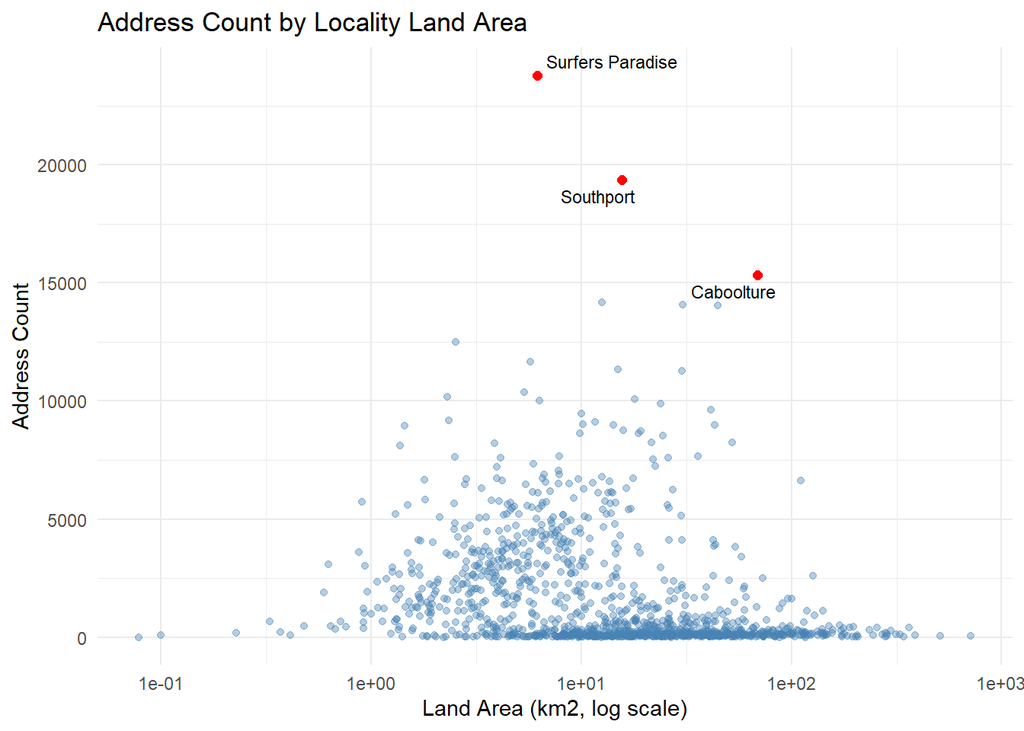

```r
locality_density %>%
  ggplot(aes(x = ca_area_sqkm, y = address_count)) +
  geom_point(alpha = 0.4, color = "steelblue") +
  geom_point(data = area_count_outliers, color = "red", size = 2) +
  geom_text_repel(data = area_count_outliers, aes(label = locality), size = 3) +
  scale_x_log10() +
  theme_minimal() +
  labs(
    title = "Address Count by Locality Land Area",
    x = "Land Area (km2, log scale)", y = "Address Count"
  )
```

#### 4.4.2 Maps

```r
localities_map_data <- localities_web %>%
  left_join(
    locality_density %>% st_drop_geometry(),
    by = "locality"
  ) %>%
  filter(address_count >= 100) %>%
  st_transform(crs = 4326)
```

Map building, centered on SEQ.

```r
pal <- colorNumeric(palette = "YlOrRd", domain = localities_map_data$density_per_sqkm, na.color = "transparent")

leaflet(localities_map_data) %>%
  addProviderTiles(providers$CartoDB.Positron) %>%
  setView(lng = 153.05, lat = -27.60, zoom = 9) %>%  # centered on South East Queensland
  addPolygons(
    fillColor = ~pal(density_per_sqkm),
    fillOpacity = 0.7,
    color = "white",
    weight = 0.5,
    label = ~paste0(locality, ": ", round(density_per_sqkm, 1), " addr/km²") %>% lapply(htmltools::HTML)
  ) %>%
  addLegend(pal = pal, values = ~density_per_sqkm, title = "Addresses per km²", position = "bottomright")
```

[interactive chart not shown]

## 5 Findings

### 5.1 Data Quality Observations

Validation of the spatial join against self-reported locality data showed a 99.91% agreement rate (1,887,592 of 1,889,301 matched records), indicating strong overall consistency between Queensland’s address register and locality boundary data sets.

### 5.2 Address Density Rankings

The ten localities with the highest address density in South East Queensland (among localities with 100 or more addresses) were Newstead, Broadbeach, Fortitude Valley, Brisbane City, Kings Beach, South Brisbane, Teneriffe, Spring Hill, West End, and Surfers Paradise with densities ranging from 6,357 to 3,854 addresses per km2.

Newstead recorded the highest address density in SEQ at 6,357 addresses per km2 despite ranking outside the top three by raw address count, its very small land area (0.90 km2) drives its density above larger, higher-count localities like Surfers Paradise (23,799 addresses, but 3,854 per km2 due to its comparatively larger 6.17 km2 footprint).

### 5.3 Geographic Patterns

The interactive map shows density concentrated heavily around inner-Brisbane suburbs, with a sharp drop-off moving away from the CBD.

The results are dominated by two clear clusters: inner-Brisbane, high-rise/mixed-use suburbs (Newstead, Fortitude Valley, Brisbane City, South Brisbane, Teneriffe, Spring Hill, West End) and Gold Coast/Sunshine Coast tourist and unit-development precincts (Broadbeach, Kings Beach, Surfers Paradise).

This pattern is consistent with known development trends in SEQ, where high-density living is concentrated around the Brisbane CBD and coastal high-rise corridors.